# IC/CP-W05 BigQuery SQL Lecture 2

Author

Roxana Rodriguez

Published

February 28, 2026

## 1 1) CTEs (WITH) to structure logic

```sql
--creates named “mini tables” inside a query.--
--Total users + new users--

WITH UserInfo AS (
SELECT
user_pseudo_id,
MAX(IF(event_name IN ('first_visit', 'first_open'), 1, 0)) AS is_new_user
FROM `bigquery-public-data.ga4_obfuscated_sample_ecommerce.events_*`
WHERE _TABLE_SUFFIX BETWEEN '20201101' AND '20201130'
GROUP BY user_pseudo_id
)
SELECT
COUNT(*) AS total_users,
SUM(is_new_user) AS new_users
FROM UserInfo;
```

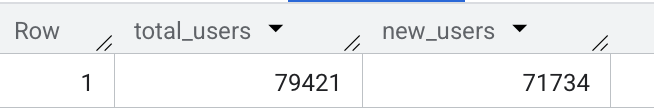

**Explanation:** The CTE creates one row per user in November 2020 and labels them as 1 if they had a first visit or first open event. Then the query counts the total users which is 79421 and the new users which is 71734.

## 2 2) Arrays + UNNEST (the GA4 superpower)

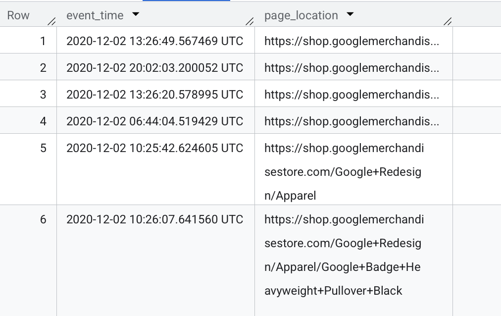

```sql
--A4 stores lots of fields inside arrays:--
--event_params (key/value pairs)--
--items (products in commerce events)--
--Two common patterns:--

--Pattern A — Scalar subquery extraction (simple, safe)--
--Pull one parameter from event_params without exploding rows.--


SELECT
TIMESTAMP_MICROS(event_timestamp) AS event_time,
(
SELECT value.string_value
FROM UNNEST(event_params)
WHERE key = 'page_location' LIMIT 1
) AS page_location
FROM `bigquery-public-data.ga4_obfuscated_sample_ecommerce.events_*`
WHERE event_name = 'page_view'
AND _TABLE_SUFFIX BETWEEN '20201201' AND '20201202'
LIMIT 50;
```

**Explanation:** This query converts the timestamp to a readable time and extracts the page_location from `event_params` , limiting the results to 50 for `event_time`, and `page_location` columns.

```sql
--Pattern B — Flattening (UNNEST in FROM) for item-level analysis--
--This multiplies rows (one event can have many items).--

SELECT
event_date,
item.item_name,
COUNT(*) AS item_rows
FROM `bigquery-public-data.ga4_obfuscated_sample_ecommerce.events_*` e,
UNNEST(e.items) AS item
WHERE e.event_name = 'purchase'
AND _TABLE_SUFFIX BETWEEN '20201201' AND '20201231'
GROUP BY event_date, item.item_name
ORDER BY item_rows DESC
LIMIT 20;

--Note: UNNEST changes the “grain.” After unnesting items, you’re no longer at “event-level”; you’re at “item-row per event.”--
```

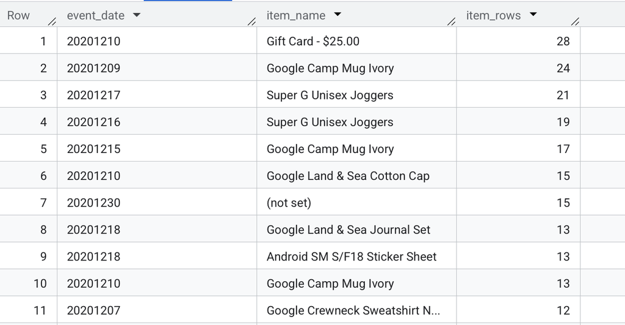

**Explanation:** For this query, it pulls the purchase events from December 2020 and unnests to access individual products. it also counts how many times each item was purchase per day, and limit the results to the top 20. Example. there were 28 gift cards purchase for December 10th, 2020.

## 3 3) STRING_AGG, ARRAY_AGG (useful aggregations)

```sql
--What they do: combine many values into one row per group.--
--Example: show a few event_names seen per day--

SELECT
event_date,
STRING_AGG(DISTINCT event_name, ', ' ORDER BY event_name) AS events_seen
FROM `bigquery-public-data.ga4_obfuscated_sample_ecommerce.events_*`
WHERE _TABLE_SUFFIX BETWEEN '20201201' AND '20201203'
GROUP BY event_date
ORDER BY event_date;
```

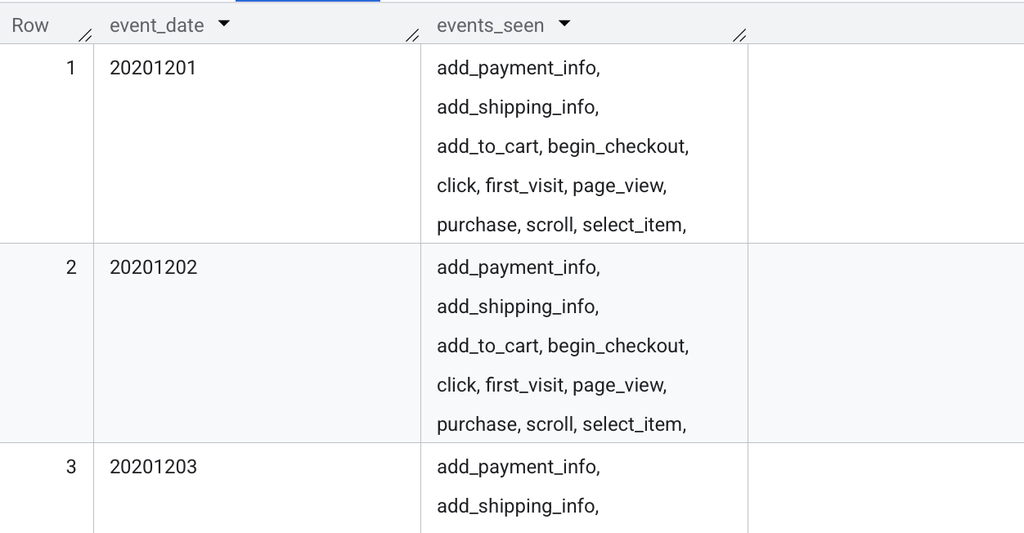

**Explanation:** This query groups data by from Dec 1st to Dec 3rd, 2020 and it lists all distinct event names in a comma separated string per date.

```sql
--Example: Build a “session cart summary” (top items a user added to cart)--
--Use Case 1:--
-- Task: Create a list of items per session

SELECT
    user_pseudo_id,
    ARRAY_AGG(item_name) AS items_added_to_cart
FROM `bigquery-public-data.ga4_obfuscated_sample_ecommerce.events_*`,
UNNEST(items) AS item
WHERE event_name = 'add_to_cart'
AND _TABLE_SUFFIX BETWEEN '20201201' AND '20201231'
GROUP BY user_pseudo_id
ORDER BY user_pseudo_id
LIMIT 10;
```

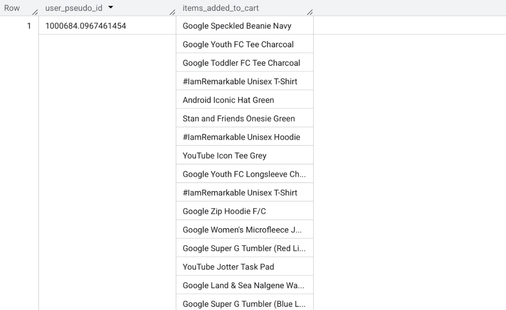

**Explanation:** This query get the `add_to_cart` events from Dec 2020, groups by `user_pseudo_id` and collect all item names they added to the cart.

```sql
--Use Case 2:--
-- Session-level "cart summary" using ARRAY_AGG

WITH add_to_cart AS (
  SELECT
    user_pseudo_id,
    (
      SELECT value.int_value
      FROM UNNEST(event_params)
      WHERE key = 'ga_session_id'
    ) AS session_id,
    TIMESTAMP_MICROS(event_timestamp) AS event_timestamp,
    i.item_id,
    i.item_name,
    i.quantity,
    i.price
  FROM `bigquery-public-data.ga4_obfuscated_sample_ecommerce.events_*`,
  UNNEST(items) AS i
  WHERE event_name = 'add_to_cart'
    AND _TABLE_SUFFIX BETWEEN '20210101' AND '20211231'  -- cost control
)
SELECT
  user_pseudo_id,
  session_id,
  COUNT(*) AS total_add_to_cart_events,              -- added insight
  ARRAY_AGG(
    STRUCT(item_id, item_name, quantity, price, event_timestamp)
    ORDER BY quantity DESC, event_timestamp ASC
    LIMIT 10
  ) AS cart_items
FROM add_to_cart
WHERE session_id IS NOT NULL                          --  filter nulls
GROUP BY user_pseudo_id, session_id;
```

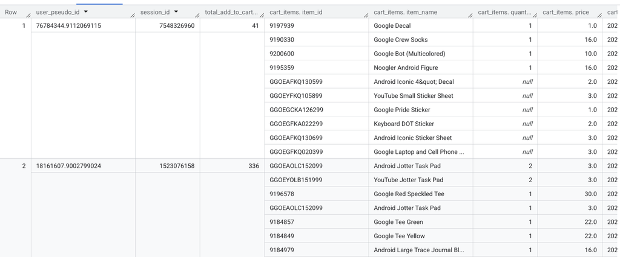

## 4 4) Joins (start with INNER and LEFT)

```sql
--Combines results based on matching keys.--
--Example: daily users joined with daily purchases (using CTEs)--

WITH daily_users AS (
  SELECT
    event_date,
    COUNT(DISTINCT user_pseudo_id) AS users
  FROM `bigquery-public-data.ga4_obfuscated_sample_ecommerce.events_*`
  WHERE _TABLE_SUFFIX BETWEEN '20201201' AND '20201231'
  GROUP BY event_date
),
daily_purchases AS (
  SELECT
    event_date,
    COUNT(DISTINCT
      (SELECT value.string_value
       FROM UNNEST(event_params)
       WHERE key = 'transaction_id')
    ) AS purchases    -- distinct transactions
  FROM `bigquery-public-data.ga4_obfuscated_sample_ecommerce.events_*`
  WHERE event_name = 'purchase'
    AND _TABLE_SUFFIX BETWEEN '20201201' AND '20201231'
  GROUP BY event_date
)
SELECT
  u.event_date,
  u.users,
  -- turns “no purchase row (NULL)” into 0 purchases, which is what you want for a daily time series
  IFNULL(p.purchases, 0) AS purchases,
  -- Conversion rate: what % of daily users made a purchase
  ROUND(
    IFNULL(p.purchases, 0) / NULLIF(u.users, 0) * 100, 2
  ) AS conversion_rate_pct        -- NULLIF prevents division by zero
FROM daily_users u
LEFT JOIN daily_purchases p
  ON u.event_date = p.event_date
ORDER BY u.event_date;
```

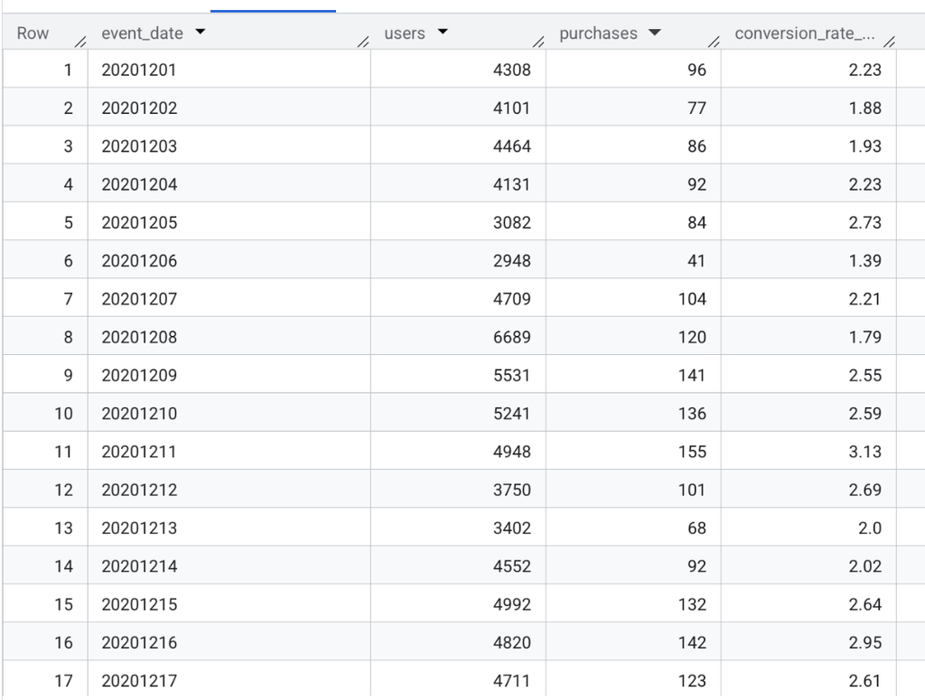

**Explanation:** This query creates daily total for unique users and distinct purchases for Dec 2020. Then the left join is used to join by date, and fill missing purchases with 0. Also, daily conversion rates is computed. The output shows that on Dec 1st, there were 4,308 users, 96 purchases and a conversion rate of 2.23%.

## 5 5) Window functions + QUALIFY

```sql
Calculate “across rows” without collapsing to
one row per group.--
--Top 3 event types per day (RANK) + QUALIFY--

WITH daily_event_counts AS (
SELECT
event_date,
event_name,
COUNT(*) AS events
FROM `bigquery-public-data.ga4_obfuscated_sample_ecommerce.events_*`
WHERE _TABLE_SUFFIX BETWEEN '20201201' AND '20201207'
GROUP BY event_date, event_name
)
SELECT
event_date,
event_name,
events,
RANK() OVER (PARTITION BY event_date ORDER BY events DESC) AS rnk
FROM daily_event_counts
QUALIFY rnk <= 3
ORDER BY event_date, rnk;

--Rolling 7-day average of daily purchases--

WITH daily_purchases AS (
SELECT
PARSE_DATE('%Y%m%d', event_date) AS dt,
COUNT(*) AS purchases
FROM `bigquery-public-data.ga4_obfuscated_sample_ecommerce.events_*`
WHERE event_name = 'purchase'
AND _TABLE_SUFFIX BETWEEN '20201201' AND '20201231' GROUP BY dt
)
SELECT
dt,
purchases,
AVG(purchases) OVER (
ORDER BY dt
ROWS BETWEEN 6 PRECEDING AND CURRENT ROW
) AS purchases_7d_avg
FROM daily_purchases
ORDER BY dt;
```

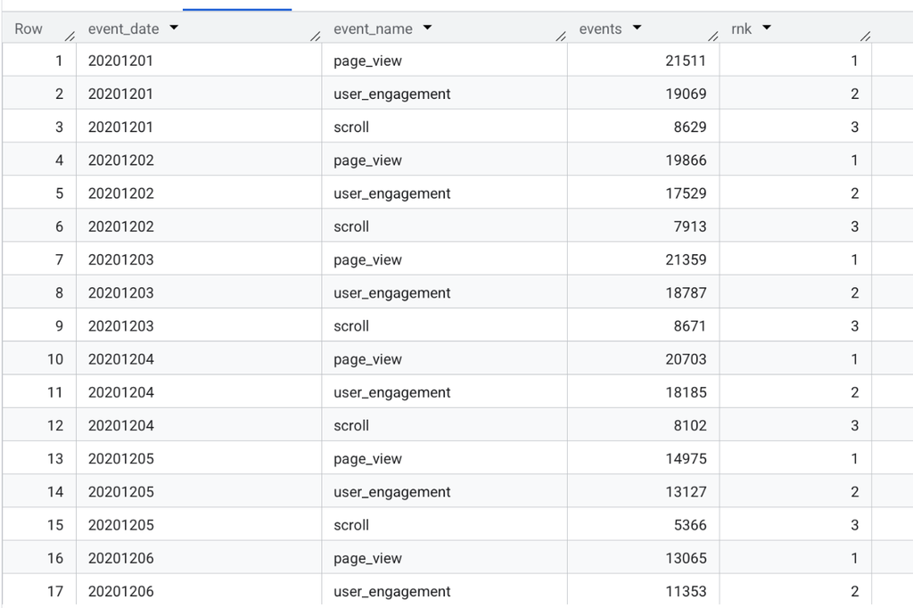

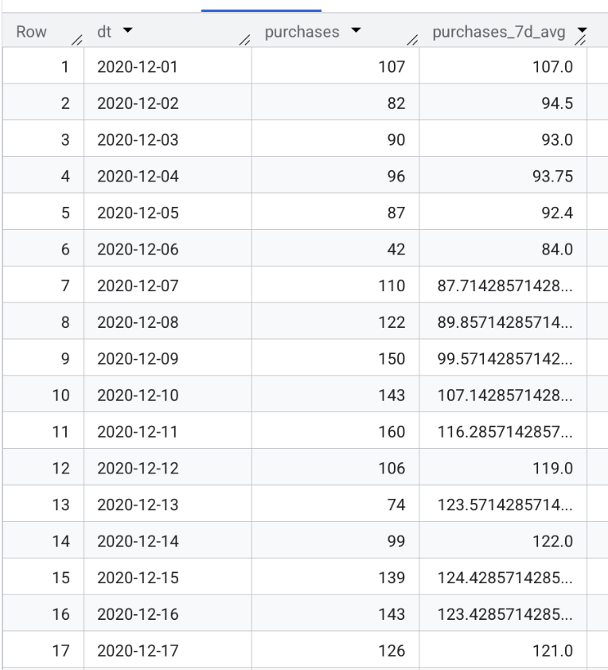

**Explanation:** The first code chunk counts event per `event_date` and `event_name` then uses RANK() to rank event types by volume and keeps 3.

The second code chunk counts daily purchases, and then computes the average across the current day and the previous 6 days and it sorts chronologically by date.

## 6 6) Approximate functions (performance-minded)

```sql
--Return “close enough” answers faster on huge datasets.--
--Approx distinct users per event type--

SELECT
event_name,
APPROX_COUNT_DISTINCT(user_pseudo_id) AS approx_users
FROM `bigquery-public-data.ga4_obfuscated_sample_ecommerce.events_*`
WHERE _TABLE_SUFFIX BETWEEN '20201201' AND '20201231'
GROUP BY event_name
ORDER BY approx_users DESC
LIMIT 15;
```

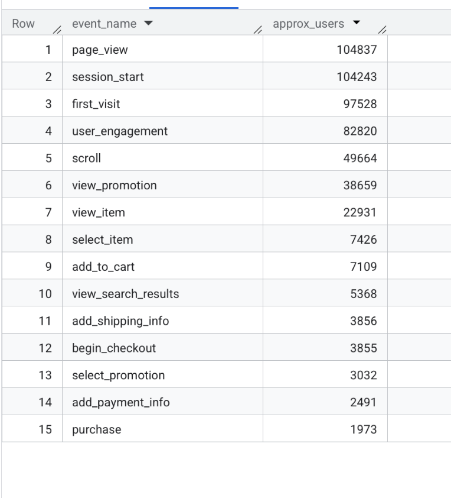

**Explanation:** This query counts the number of distinct users per `event_name` and it sorts by the highest user count, limiting the results to 15 events.